# 🔧 Data Preprocessing

### Корреляции.

```
=============================================================================================================================
Анализ корреляций для таблицы: CLOSED_DEALS
=============================================================================================================================
```

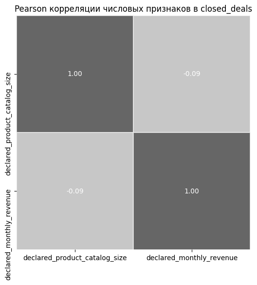

```
Нет сильно коррелирующих признаков по выбранному порогу.

=============================================================================================================================
Анализ корреляций для таблицы: CUSTOMERS
=============================================================================================================================
Нет сильно коррелирующих признаков по выбранному порогу.

=============================================================================================================================
Анализ корреляций для таблицы: GEOLOCATION
=============================================================================================================================
```

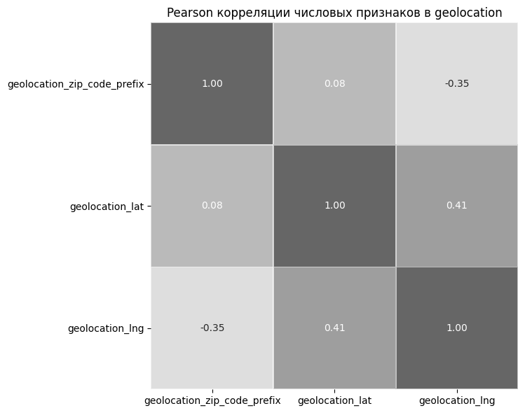

```
Нет сильно коррелирующих признаков по выбранному порогу.

=============================================================================================================================
Анализ корреляций для таблицы: MARKETING_QUALIFIED
=============================================================================================================================
Нет числовых признаков в таблице marketing_qualified. Пропускаем.

=============================================================================================================================
Анализ корреляций для таблицы: ORDERS
=============================================================================================================================
Нет числовых признаков в таблице orders. Пропускаем.

=============================================================================================================================
Анализ корреляций для таблицы: ORDER_ITEMS
=============================================================================================================================
```

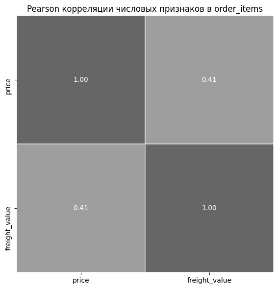

```
Нет сильно коррелирующих признаков по выбранному порогу.

=============================================================================================================================
Анализ корреляций для таблицы: ORDER_PAYMENTS
=============================================================================================================================
```

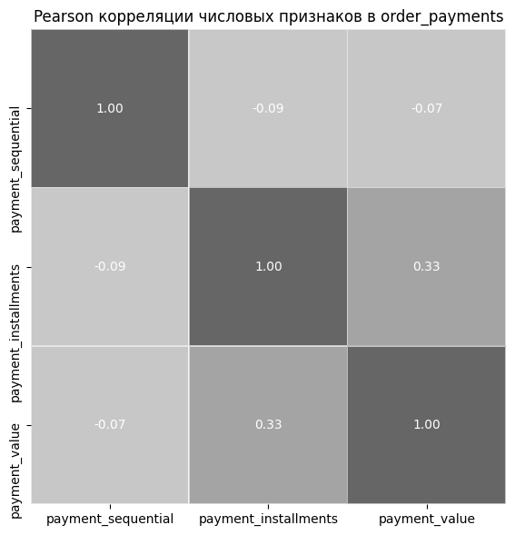

```
Нет сильно коррелирующих признаков по выбранному порогу.

=============================================================================================================================
Анализ корреляций для таблицы: ORDER_REVIEWS
=============================================================================================================================
Нет сильно коррелирующих признаков по выбранному порогу.

=============================================================================================================================
Анализ корреляций для таблицы: PRODUCTS
=============================================================================================================================
```

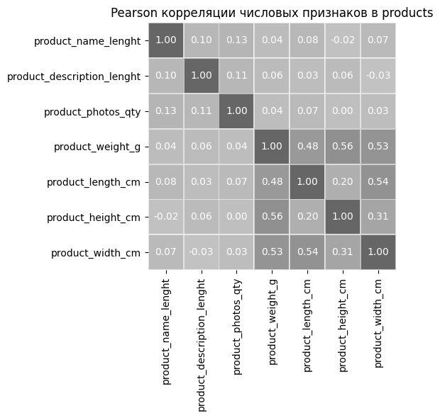

```
product_weight_g и product_height_cm: прямая корреляция 0.56 (pearson)
product_weight_g и product_width_cm: прямая корреляция 0.53 (pearson)
product_length_cm и product_width_cm: прямая корреляция 0.54 (pearson)

=============================================================================================================================
Анализ корреляций для таблицы: SELLERS
=============================================================================================================================
Нет сильно коррелирующих признаков по выбранному порогу.

✅ Анализ корреляций завершен!
```

```python
from src.corr_features import analyze_correlations
analyze_correlations(dfso, method="pearson", threshold=0.5)
```

## 5. 🛠️ Подготовка к загрузке в Supabase

- Ручная проверка нормализованной схемы таблиц.
- Проверка первичных и внешних ключей.
- Генерация схемы таблиц (DDL) для PostgreSQL (или автоматическая миграция).
- Сопоставление колонок с типами (`VARCHAR`, `INTEGER`, `TIMESTAMP`, `FLOAT`, `BOOLEAN`).

📌 *Цель: привести структуру к формату, пригодному для аналитической базы данных.*

### Добавим словарь Foreign Keys.

```python
# Словарь первичных ключей
pk = {
    "order_items": ["order_id", "order_item_id"],
    "orders": ["order_id"],
    "customers": ["customer_id"],
    "products": ["product_id"],
    "order_reviews": ["review_id"],
    "sellers": ["seller_id"],
    "closed_deals": ["mql_id"]
}

# Словарь вторичных ключей
fk = {
    "order_items": {
        "order_id": "orders(order_id)",
        "product_id": "products(product_id)",
        "seller_id": "sellers(seller_id)"
    },
    "orders": {
        "customer_id": "customers(customer_id)",
    },
    "order_reviews": {
        "order_id": "orders(order_id)"
    },
    "order_payments": {
        "order_id": "orders(order_id)"
    },
#    "customers": {
#        "zip": "geolocation(zip)"
#    },
#    "sellers": {
#        "zip": "geolocation(zip)"
#   },

    "closed_deals": {
        "seller_id": "sellers(seller_id)"
    },
    "marketing_qualified": {
        "mql_id": "closed_deals(mql_id)"
    }
}
```

### Выполним проверку и очистку данных.

```python
def validate_and_clean_data(
    dfso: dict,
    fk_dict: dict,
    verbose: bool = True
) -> tuple[dict, dict]:
    """
    Автоматическая проверка и очистка данных на основе словаря внешних ключей

    Параметры:
        dfso: Словарь с DataFrame
        fk_dict: Словарь внешних ключей в формате {таблица: {столбец: ссылка}}
        verbose: Флаг вывода подробной информации

    Возвращает:
        Кортеж (очищенные данные, статистика удалений)
    """

    stats = {}
    cleaned_dfs = dfso.copy()

    # Проход по всем таблицам с FK
    for child_table, fks in fk_dict.items():
        if child_table not in cleaned_dfs:
            if verbose:
                print(f"⚠️ Таблица {child_table} отсутствует в данных, пропускаем...")
            continue

        df = cleaned_dfs[child_table].copy()
        initial_count = len(df)

        for fk_column, ref in fks.items():
            # Парсим ссылку: parent_table(parent_column)
            ref_match = re.match(r"(\w+)\((\w+)\)", ref)
            if not ref_match:
                raise ValueError(f"Некорректный формат ссылки: {ref}")

            parent_table, parent_column = ref_match.groups()

            # Проверка существования родительской таблицы
            if parent_table not in cleaned_dfs:
                raise ValueError(f"Родительская таблица {parent_table} не найдена")

            # Получаем валидные ключи
            valid_keys = set(cleaned_dfs[parent_table][parent_column].unique())

            # Фильтрация данных
            mask = df[fk_column].isin(valid_keys)
            invalid_count = (~mask).sum()

            if verbose:
                print(f"🔍 {child_table}.{fk_column} → {parent_table}.{parent_column}")
                print(f"   Найдено некорректных записей: {invalid_count} ({invalid_count/len(df):.1%})")

            df = df[mask].copy()

            # Обновляем статистику
            stats_key = f"{child_table}.{fk_column}"
            stats[stats_key] = stats.get(stats_key, 0) + invalid_count

        # Сохраняем очищенные данные
        cleaned_dfs[child_table] = df
        if verbose:
            print(f"✅ {child_table}: Удалено {initial_count - len(df)} записей")

    return cleaned_dfs, stats
```

```python
cleaned_dfs, stats =  validate_and_clean_data(dfso, fk)
```

```
🔍 order_items.order_id → orders.order_id
   Найдено некорректных записей: 0 (0.0%)
🔍 order_items.product_id → products.product_id
   Найдено некорректных записей: 1627 (1.4%)
🔍 order_items.seller_id → sellers.seller_id
   Найдено некорректных записей: 0 (0.0%)
✅ order_items: Удалено 1627 записей
🔍 orders.customer_id → customers.customer_id
   Найдено некорректных записей: 0 (0.0%)
✅ orders: Удалено 0 записей
🔍 order_reviews.order_id → orders.order_id
   Найдено некорректных записей: 0 (0.0%)
✅ order_reviews: Удалено 0 записей
🔍 order_payments.order_id → orders.order_id
   Найдено некорректных записей: 0 (0.0%)
✅ order_payments: Удалено 0 записей
🔍 closed_deals.seller_id → sellers.seller_id
   Найдено некорректных записей: 462 (54.9%)
✅ closed_deals: Удалено 462 записей
🔍 marketing_qualified.mql_id → closed_deals.mql_id
   Найдено некорректных записей: 7620 (95.2%)
✅ marketing_qualified: Удалено 7620 записей
```

## 6. ☁️ Загрузка данных в Supabase (PostgreSQL)

- Использование Python (например, через SQLAlchemy/`psycopg2`) для загрузки очищенных датафреймов.
- Журналирование:
  - лог успешной загрузки,
  - контроль типов и размерностей.
- Валидация:
  - проверки внешних ключей (`customer_id`, `order_id`, `product_id`),
  - проверка отсутствия дубликатов.

📌 *Цель: создать чистую, нормализованную, согласованную PostgreSQL-базу под аналитические запросы.*

```python
# pipeline.py

import pandas as pd
import re
from sqlalchemy import create_engine, text
from sqlalchemy.pool import NullPool
from sqlalchemy.exc import ProgrammingError
from dotenv import load_dotenv
import os
import time
from tqdm import tqdm

from src.db_utils import get_engine

# Используем заранее подготовленный скрипт для подключения к БД
engine = get_engine()

# === Утилиты === #
def map_dtype(dtype):
    if pd.api.types.is_string_dtype(dtype):
        return 'VARCHAR'
    elif pd.api.types.is_integer_dtype(dtype):
        return 'INTEGER'
    elif pd.api.types.is_float_dtype(dtype):
        return 'FLOAT'
    elif pd.api.types.is_bool_dtype(dtype):
        return 'BOOLEAN'
    elif pd.api.types.is_datetime64_any_dtype(dtype):
        return 'TIMESTAMP'
    else:
        return 'VARCHAR'

def to_snake_case(name):
    return re.sub(r'(?<!^)(?=[A-Z])', '_', name).lower().strip()

# === Генерация DDL === #
def generate_clean_ddl(df_dict, pk_dict):
    ddl_statements = {}
    for table_name, df in df_dict.items():
        table_snake = to_snake_case(table_name)
        lines = [f"CREATE TABLE IF NOT EXISTS {table_snake} ("]
        col_defs = []

        for col in df.columns:
            col_snake = to_snake_case(col)
            sql_type = map_dtype(df[col])
            col_defs.append(f"    {col_snake} {sql_type}")
        lines.extend([line + "," for line in col_defs])

        # Уточнённая логика добавления PK
        if table_name in pk_dict:
            pk_cols = [to_snake_case(col) for col in pk_dict[table_name]]
            pk_line = f"    PRIMARY KEY ({', '.join(pk_cols)})"
            lines.append(pk_line)

        lines[-1] = lines[-1].rstrip(",")
        lines.append(");")
        ddl_statements[table_snake] = "\n".join(lines)
    return ddl_statements

# === Создание таблиц === #
def create_tables_from_ddl(ddl_statements, engine):
    with engine.connect() as conn:
        for table, ddl in tqdm(ddl_statements.items(), desc="🔧 Creating tables"):
            try:
                conn.execute(text(ddl))
                print(f"✅ Created: {table}")
            except Exception as e:
                print(f"❌ Error creating table {table}: {e}")

# === Проверка на существование таблицы и данных === #
def table_has_data(table_name, engine):
    query = f"SELECT COUNT(*) FROM {table_name}"
    try:
        with engine.connect() as conn:
            result = conn.execute(text(query))
            count = result.scalar()
            return count > 0
    except ProgrammingError:
        return False  # таблицы ещё нет

# === Загрузка данных с проверкой === #
def upload_dfso_to_db_safe(df_dict, engine):
    for table_name, df in tqdm(df_dict.items(), desc="⬆️ Uploading data"):
        table_snake = to_snake_case(table_name)
        if table_has_data(table_snake, engine):
            print(f"⚠️ Skipping {table_snake} — already filled.")
            continue

        print(f"⬆️ Uploading: {table_snake}")
        try:
            df.columns = [to_snake_case(col) for col in df.columns]
            df.to_sql(
                table_snake,
                con=engine,
                if_exists='append',
                index=False,
                chunksize=1000
            )
            print(f"✅ Uploaded: {table_snake}")
        except Exception as e:
            print(f"❌ Error uploading {table_snake}: {e}")
            print("⏳ Waiting 10 seconds before retry...")
            time.sleep(10)
            try:
                df.to_sql(
                    table_snake,
                    con=engine,
                    if_exists='append',
                    index=False,
                    chunksize=1000
                )
                print(f"✅ Retried and uploaded: {table_snake}")
            except Exception as e:
                print(f"🚫 Second attempt failed for {table_snake}: {e}")

# === Финальная функция запуска === #
def run_full_pipeline(dfso, engine, pk_dict):
    print("📌 Starting pipeline...")
    ddl_dict = generate_clean_ddl(dfso, pk_dict)
    create_tables_from_ddl(ddl_dict, engine)
    upload_dfso_to_db_safe(dfso, engine)
    print("🏁 Pipeline completed.")
```

```python
#from pipeline import run_full_pipeline, engine

pk = {
    "order_items": ["order_id", "order_item_id"],
    "orders": ["order_id"],
    "customers": ["customer_id"],
    "products": ["product_id"],
    "order_reviews": ["review_id"],
    "sellers": ["seller_id"],
    "closed_deals": ["mql_id"]
}

run_full_pipeline(dfso, engine, pk)
```

```
📌 Starting pipeline...
```

```
✅ Created: closed_deals
✅ Created: customers
✅ Created: geolocation
✅ Created: marketing_qualified
```

```
✅ Created: orders
✅ Created: order_items
✅ Created: order_payments
```

```
✅ Created: order_reviews
✅ Created: products
✅ Created: sellers
```

```
⚠️ Skipping closed_deals — already filled.
```

```
⚠️ Skipping customers — already filled.
```

```
⚠️ Skipping geolocation — already filled.
⚠️ Skipping marketing_qualified — already filled.
```

```
⚠️ Skipping orders — already filled.
```

```
⚠️ Skipping order_items — already filled.
```

```
⚠️ Skipping order_payments — already filled.
```

```
⚠️ Skipping order_reviews — already filled.
```

```
⚠️ Skipping products — already filled.
⚠️ Skipping sellers — already filled.
```

```
🏁 Pipeline completed.
```

### Выполним валидацию результатов

```python
def validate_tables_exist(engine, table_names):
    with engine.connect() as conn:
        for table_name in table_names:
            result = conn.execute(text(f"SELECT to_regclass('{table_name}');"))
            if result.fetchone()[0] is None:
                print(f"❌ Table {table_name} does not exist.")
            else:
                print(f"✅ Table {table_name} exists.")

def validate_row_count(engine, df_dict):
    with engine.connect() as conn:
        for table_name, df in df_dict.items():
            table_snake = to_snake_case(table_name)
            result = conn.execute(text(f"SELECT COUNT(*) FROM {table_snake};"))
            db_row_count = result.fetchone()[0]
            df_row_count = len(df)
            if db_row_count == df_row_count:
                print(f"✅ Row count matches for {table_snake}: {db_row_count} rows.")
            else:
                print(f"❌ Row count mismatch for {table_snake}: Expected {df_row_count}, got {db_row_count}.")

def validate_data_types(engine, df_dict):
    with engine.connect() as conn:
        for table_name, df in df_dict.items():
            table_snake = to_snake_case(table_name)
            for col in df.columns:
                col_snake = to_snake_case(col)
                # Получаем тип данных из базы данных
                result = conn.execute(text(f"SELECT data_type FROM information_schema.columns WHERE table_name = '{table_snake}' AND column_name = '{col_snake}';"))
                db_data_type = result.fetchone()[0]
                # Проверяем соответствие типов данных
                expected_type = map_dtype(df[col])
                if db_data_type.lower() == expected_type.lower():
                    print(f"✅ Data type matches for {table_snake}.{col_snake}: {db_data_type}.")
                else:
                    print(f"❌ Data type mismatch for {table_snake}.{col_snake}: Expected {expected_type}, got {db_data_type}.")

def validate_data_types(engine, df_dict):
    with engine.connect() as conn:
        for table_name, df in df_dict.items():
            table_snake = to_snake_case(table_name)
            for col in df.columns:
                col_snake = to_snake_case(col)

                # Проверяем существование колонки
                col_exists = conn.execute(text(
                    f"SELECT EXISTS ("
                    f"SELECT 1 FROM information_schema.columns "
                    f"WHERE table_name = '{table_snake}' "
                    f"AND column_name = '{col_snake}'"
                    f");"
                )).scalar()

                if not col_exists:
                    print(f"⚠️ Column {table_snake}.{col_snake} does not exist in DB")
                    continue

                # Получаем тип данных из БД
                result = conn.execute(text(
                    f"SELECT data_type FROM information_schema.columns "
                    f"WHERE table_name = '{table_snake}' "
                    f"AND column_name = '{col_snake}';"
                ))
                db_data_type = result.fetchone()[0].lower()

                # Уточнённый маппинг типов
                dtype_map = {
                    'object': 'text',
                    'int64': 'integer',
                    'float64': 'double precision',
                    'bool': 'boolean',
                    'datetime64[ns]': 'timestamp without time zone'
                }
                expected_type = dtype_map.get(str(df[col].dtype), 'text')

                # Нормализация названий типов
                type_aliases = {
                    'varchar': 'text',
                    'timestamp': 'timestamp without time zone'
                }
                db_data_type = type_aliases.get(db_data_type, db_data_type)

                if db_data_type == expected_type:
                    print(f"✅ {table_snake}.{col_snake}: {db_data_type}")
                else:
                    print(f"❌ {table_snake}.{col_snake}: "
                          f"DB имеет {db_data_type}, ожидался {expected_type}")

def validate_missing_values(engine, df_dict):
    with engine.connect() as conn:
        for table_name, df in df_dict.items():
            table_snake = to_snake_case(table_name)
            for col in df.columns:
                col_snake = to_snake_case(col)
                # Проверяем наличие пропусков в базе данных
                result = conn.execute(text(f"SELECT COUNT(*) FROM {table_snake} WHERE {col_snake} IS NULL;"))
                db_null_count = result.fetchone()[0]
                df_null_count = df[col].isnull().sum()
                if db_null_count == df_null_count:
                    print(f"✅ Missing values match for {table_snake}.{col_snake}: {db_null_count} missing values.")
                else:
                    print(f"❌ Missing values mismatch for {table_snake}.{col_snake}: Expected {df_null_count}, got {db_null_count}.")



def validate_primary_keys(engine, df_dict):
    with engine.connect() as conn:
        for table_name, df in df_dict.items():
            table_snake = to_snake_case(table_name)
            # Пример для первичного ключа
            primary_key_col = f"{table_snake[:-1]}_id"  # Предполагаем, что первичный ключ имеет такое название
            if primary_key_col in [to_snake_case(c) for c in df.columns]:
                result = conn.execute(text(f"SELECT COUNT(DISTINCT {primary_key_col}) FROM {table_snake};"))
                db_unique_count = result.fetchone()[0]
                df_unique_count = df[primary_key_col].nunique()
                if db_unique_count == df_unique_count:
                    print(f"✅ Unique values match for {table_snake}.{primary_key_col}: {db_unique_count} unique values.")
                else:
                    print(f"❌ Unique values mismatch for {table_snake}.{primary_key_col}: Expected {df_unique_count}, got {db_unique_count}.")


def run_validation(dfso, engine):
    print("📌 Starting validation...")
    table_names = [to_snake_case(table_name) for table_name in dfso.keys()]

    # Проверка наличия таблиц
    validate_tables_exist(engine, table_names)

    # Проверка количества строк
    validate_row_count(engine, dfso)

    # Проверка типов данных
    validate_data_types(engine, dfso)

    # Проверка пропусков
    validate_missing_values(engine, dfso)

    # Проверка уникальности первичных ключей
    validate_primary_keys(engine, dfso)

    print("🏁 Validation completed.")
```

```python
run_validation(dfso, engine)
```

```
📌 Starting validation...
✅ Table closed_deals exists.
✅ Table customers exists.
✅ Table geolocation exists.
✅ Table marketing_qualified exists.
✅ Table orders exists.
✅ Table order_items exists.
✅ Table order_payments exists.
✅ Table order_reviews exists.
✅ Table products exists.
✅ Table sellers exists.
✅ Row count matches for closed_deals: 842 rows.
✅ Row count matches for customers: 99441 rows.
✅ Row count matches for geolocation: 738332 rows.
✅ Row count matches for marketing_qualified: 8000 rows.
✅ Row count matches for orders: 99441 rows.
✅ Row count matches for order_items: 112650 rows.
✅ Row count matches for order_payments: 103886 rows.
✅ Row count matches for order_reviews: 99224 rows.
✅ Row count matches for products: 32328 rows.
✅ Row count matches for sellers: 3095 rows.
✅ closed_deals.mql_id: text
✅ closed_deals.seller_id: text
✅ closed_deals.sdr_id: text
✅ closed_deals.sr_id: text
✅ closed_deals.won_date: timestamp without time zone
✅ closed_deals.business_segment: text
✅ closed_deals.lead_type: text
✅ closed_deals.lead_behaviour_profile: text
✅ closed_deals.has_company: boolean
✅ closed_deals.has_gtin: boolean
✅ closed_deals.business_type: text
✅ closed_deals.declared_product_catalog_size: double precision
❌ closed_deals.declared_monthly_revenue: DB имеет integer, ожидался text
✅ customers.customer_id: text
✅ customers.customer_unique_id: text
❌ customers.customer_zip_code_prefix: DB имеет integer, ожидался text
✅ customers.customer_city: text
✅ customers.customer_state: text
❌ geolocation.geolocation_zip_code_prefix: DB имеет integer, ожидался text
```

[output cut: 93 more lines]

```
✅ Missing values match for order_payments.payment_sequential: 0 missing values.
✅ Missing values match for order_payments.payment_type: 0 missing values.
✅ Missing values match for order_payments.payment_installments: 0 missing values.
✅ Missing values match for order_payments.payment_value: 0 missing values.
✅ Missing values match for order_reviews.review_id: 0 missing values.
✅ Missing values match for order_reviews.order_id: 0 missing values.
✅ Missing values match for order_reviews.review_score: 0 missing values.
✅ Missing values match for order_reviews.review_comment_title: 0 missing values.
✅ Missing values match for order_reviews.review_comment_message: 0 missing values.
✅ Missing values match for order_reviews.review_creation_date: 0 missing values.
✅ Missing values match for order_reviews.review_answer_timestamp: 0 missing values.
✅ Missing values match for products.product_id: 0 missing values.
✅ Missing values match for products.product_name_lenght: 0 missing values.
✅ Missing values match for products.product_description_lenght: 0 missing values.
✅ Missing values match for products.product_photos_qty: 0 missing values.
```

```
✅ Missing values match for products.product_weight_g: 0 missing values.
✅ Missing values match for products.product_length_cm: 0 missing values.
✅ Missing values match for products.product_height_cm: 0 missing values.
✅ Missing values match for products.product_width_cm: 0 missing values.
✅ Missing values match for products.product_category_name_english: 0 missing values.
✅ Missing values match for products.category_name_translated: 0 missing values.
✅ Missing values match for products.category_name_grouped: 26 missing values.
✅ Missing values match for sellers.seller_id: 0 missing values.
✅ Missing values match for sellers.seller_zip_code_prefix: 0 missing values.
✅ Missing values match for sellers.seller_city: 0 missing values.
✅ Missing values match for sellers.seller_state: 0 missing values.
✅ Unique values match for customers.customer_id: 99441 unique values.
✅ Unique values match for orders.order_id: 99441 unique values.
✅ Unique values match for order_items.order_item_id: 21 unique values.
✅ Unique values match for products.product_id: 32328 unique values.
✅ Unique values match for sellers.seller_id: 3095 unique values.
🏁 Validation completed.
```

## ✅ Вывод

Следующим этапом станет **аналитическая трансформация и создание витрин**, на которых будут построены ключевые продуктовые метрики.

```python
import os
from dotenv import load_dotenv
import subprocess

load_dotenv()

user = os.getenv("user")
password = os.getenv("password")
host = os.getenv("host")
port = os.getenv("port")
dbname = os.getenv("dbname")

db_url = f"postgresql+psycopg2://{user}:{password}@{host}:{port}/{dbname}"

# 1. Генерация .dot-файла
subprocess.run(["eralchemy", "-i", db_url, "-o", "schema.dot", "--exclude-tables", "^pg_.*,^sql_.*"])

# 2. Конвертация в картинку
subprocess.run(["dot", "-Tpng", "schema.dot", "-o", "schema.png"])

print("✅ ER-диаграмма сохранена как schema.png")
```

```
✅ ER-диаграмма сохранена как schema.png
```

```python
dfso['marketing_qualified'].info()
```

```
<class 'pandas.core.frame.DataFrame'>
RangeIndex: 8000 entries, 0 to 7999
Data columns (total 4 columns):
 #   Column              Non-Null Count  Dtype
---  ------              --------------  -----
 0   mql_id              8000 non-null   object
 1   first_contact_date  8000 non-null   datetime64[ns]
 2   landing_page_id     8000 non-null   object
 3   origin              8000 non-null   category
dtypes: category(1), datetime64[ns](1), object(2)
memory usage: 195.8+ KB
```

```python
dfso['closed_deals'].info()
```

```
<class 'pandas.core.frame.DataFrame'>
RangeIndex: 842 entries, 0 to 841
Data columns (total 13 columns):
 #   Column                         Non-Null Count  Dtype
---  ------                         --------------  -----
 0   mql_id                         842 non-null    object
 1   seller_id                      842 non-null    object
 2   sdr_id                         842 non-null    object
 3   sr_id                          842 non-null    object
 4   won_date                       842 non-null    datetime64[ns]
 5   business_segment               842 non-null    category
 6   lead_type                      842 non-null    category
 7   lead_behaviour_profile         842 non-null    category
 8   has_company                    842 non-null    bool
 9   has_gtin                       842 non-null    bool
 10  business_type                  842 non-null    category
 11  declared_product_catalog_size  69 non-null     float64
 12  declared_monthly_revenue       842 non-null    int32
dtypes: bool(2), category(4), datetime64[ns](1), float64(1), int32(1), object(4)
memory usage: 50.0+ KB
```